# Partie I - (Données du système Ford GoBike:201902-fordgobike-tripdata)

## Analyse Bivariée

### Préparation des données

#### Définition

Daprès ce qui précède , nous avons scindé notre jeu de données en classe de duurée de trajet et pour tenir compte de cette aspect dans l'exploration bivalente, nous allons ajoutée une variable "type_trip" dans notre jeu de données.

#### Code

```python
type1["type_trip"] = "type_1"
type2["type_trip"] = "type_2"
type3["type_trip"] = "type_3"
type4["type_trip"] = "type_4"
type5["type_trip"] = "type_5"
type6["type_trip"] = "type_6"
```

[output not shown]

```python
df_clean =pd.concat([type1, type2, type3, type4, type5, type6], ignore_index=True)
```

#### Test

```python
df_clean.shape
```

```
(174952, 16)
```

```python
df_clean.head()
```

|  | duration_sec | start_time | start_station_id | start_station_latitude | start_station_longitude | end_station_id | end_station_latitude | end_station_longitude | bike_id | user_type | member_birth_year | member_gender | bike_share_for_all_trip | start_period | start_Week | type_trip |
| --- | --- | --- | --- | --- | --- | --- | --- | --- | --- | --- | --- | --- | --- | --- | --- | --- |
| 0 | 1147 | 2019/02/28 | 300.0 | 37.317298 | -121.884995 | 312.0 | 37.329732 | -121.901782 | 3803 | Subscriber | 1983.0 | Female | No | 23 | le 28 | type_1 |
| 1 | 1049 | 2019/02/28 | 19.0 | 37.788975 | -122.403452 | 121.0 | 37.759210 | -122.421339 | 6488 | Subscriber | 1992.0 | Male | No | 23 | le 28 | type_1 |
| 2 | 458 | 2019/02/28 | 370.0 | 37.787327 | -122.413278 | 43.0 | 37.778768 | -122.415929 | 5318 | Subscriber | 1996.0 | Female | Yes | 23 | le 28 | type_1 |
| 3 | 506 | 2019/02/28 | 44.0 | 37.781074 | -122.411738 | 343.0 | 37.783172 | -122.393572 | 5848 | Subscriber | 1993.0 | Male | No | 23 | le 28 | type_1 |
| 4 | 1176 | 2019/02/28 | 127.0 | 37.756708 | -122.421025 | 323.0 | 37.798014 | -122.405950 | 5328 | Customer | 1990.0 | Male | No | 23 | le 28 | type_1 |

#### Question #9

Existe -t-il une relation entre de la durée des trajets par type de trajet?

#### Visualisation # 9

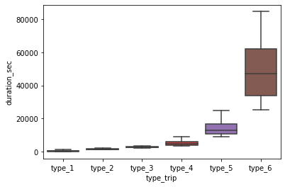

```python
#plt.figure(figsize=[10,10]);
sb.boxplot(data=df_clean, x= 'type_trip', y='duration_sec');
```

#### Observation #9

On remarque bien une forte relation lineaire entre durée de trajet et type de trajet.

#### Question #10

Le type d'utilisateur dépend-t-il du type de trajet?

#### Visualisation # 10

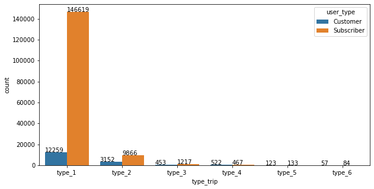

```python
# observation 'type_trip' Vs 'user_type'
plt.figure(figsize=[10,5])
ax = sb.countplot(data = df_clean, x = 'type_trip', hue = 'user_type');

for p in ax.patches:
    width, height = p.get_width(), p.get_height()
    x, y = p.get_xy()
    ax.annotate((height), (x, y + height))
```

#### Question #11

Le type d'utilisateur dépend -t-il du fait qu'un vélo soit du type tout déplacement ou non?

#### Visualisation #11

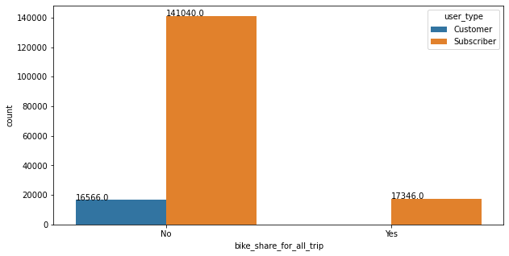

```python
plt.figure(figsize=[10,5])
ax = sb.countplot(data = df_clean, x = 'bike_share_for_all_trip', hue ='user_type')

for p in ax.patches:
    width, height = p.get_width(), p.get_height()
    x, y = p.get_xy()
    ax.annotate((height), (x, y + height))
```

#### Oservation #11

D'après ce graphe, nous remarquons que : Aucun utilisateur du type client ne dispose d'un vélo du type tout déplacement. Dès lors, il semble que le fait que le vélo soit du type tout déplacement ou pas semble influencer le type d'ultilisateur.

#### Question #12

Le type d'utilisateur dépend-t-il du sexe de l'utilisateur?

#### Visualisation #12

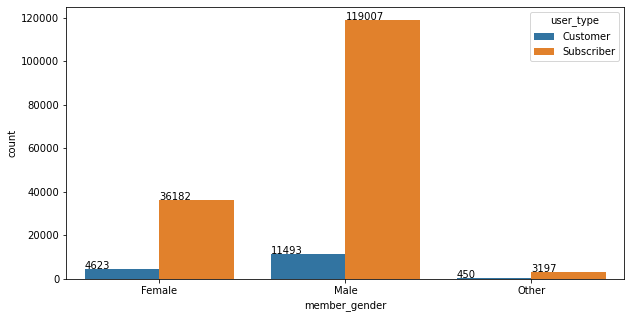

```python
plt.figure(figsize=[10,5])
ax = sb.countplot(data = df_clean, x = 'member_gender', hue ='user_type')

for p in ax.patches:
    width, height = p.get_width(), p.get_height()
    x, y = p.get_xy()
    ax.annotate((height), (x, y + height))
```

#### Observation #12

Nous remarquons que quelque ce soit le type d'utlisateur nous avons plus d'hommes que autres genres(Femmes et Other). Dès, le fait d'un utilisateur soit un abonné ou un client ne semble pas être directement affecté par le son sexe.

#### Question #13

Le fait qu'un utilisateur soit client ou abonné dépend-t-il de la semaine dans laquelle il effectue son trajet?

#### Visualisation #13

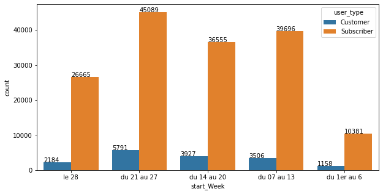

```python
plt.figure(figsize=[10,5])
ax = sb.countplot(data = df_clean, x = 'start_Week', hue ='user_type')

for p in ax.patches:
    width, height = p.get_width(), p.get_height()
    x, y = p.get_xy()
    ax.annotate((height), (x, y + height))
```

## Analyse Multivariée

> Nous créerons dans cette partie des graphiques de trois variables ou plus pour approfondir notre investigation sur des données.

#### Question #14

Connaisant le type du trajet, le fait d'être un client ou un abonné dépend-il du sexe?

```python
recode_member_gender ={'Male':'M', 'Female':'F', 'Other':'O'}
type1.replace(recode_member_gender, inplace = True)
type2.replace(recode_member_gender, inplace = True)
type3.replace(recode_member_gender, inplace = True)
type4.replace(recode_member_gender, inplace = True)
type5.replace(recode_member_gender, inplace = True)
type6.replace(recode_member_gender, inplace = True)
```

### Les différents tableaux croisés type d'ulisateur par sexe connaissant le type de trajet

```python
# les différents tableaux croisés du sexe et type d'ulisateur connaissant le type de trajet
Type1=pd.pivot_table(type1[['user_type','member_gender']],index=['member_gender'],columns=['user_type'],aggfunc=len)
Type2=pd.pivot_table(type2[['user_type','member_gender']],index=['member_gender'],columns=['user_type'],aggfunc=len)
Type3=pd.pivot_table(type3[['user_type','member_gender']],index=['member_gender'],columns=['user_type'],aggfunc=len)
Type4=pd.pivot_table(type4[['user_type','member_gender']],index=['member_gender'],columns=['user_type'],aggfunc=len)
Type5=pd.pivot_table(type5[['user_type','member_gender']],index=['member_gender'],columns=['user_type'],aggfunc=len)
Type6=pd.pivot_table(type6[['user_type','member_gender']],index=['member_gender'],columns=['user_type'],aggfunc=len)
print(f"Sahant que le trajet est de type_1")
print(f'{Type1}\n')
print(f"Sahant que le trajet est de type_2")
print(f'{Type2}\n')
print(f"Sahant que le trajet est de type_3")
print(f'{Type3}\n')
print(f"Sahant que le trajet est de type_4")
print(f'{Type4}\n')
print(f"Sahant que le trajet est de type_5")
print(f'{Type5}\n')
print(f"Sahant que le trajet est de type_6")
print(f'{Type6}\n')
```

```
Sahant que le trajet est de type_1
user_type      Customer  Subscriber
member_gender
F                  3225       33028
M                  8688      110786
O                   346        2805

Sahant que le trajet est de type_2
user_type      Customer  Subscriber
member_gender
F                  1003        2669
M                  2070        6925
O                    79         272

Sahant que le trajet est de type_3
user_type      Customer  Subscriber
member_gender
F                   163         331
M                   281         824
O                     9          62

Sahant que le trajet est de type_4
user_type      Customer  Subscriber
member_gender
F                   172          92
M                   342         336
O                     8          39

Sahant que le trajet est de type_5
user_type      Customer  Subscriber
member_gender
F                    43          40
M                    77          84
O                     3           9

Sahant que le trajet est de type_6
user_type      Customer  Subscriber
member_gender
F                    17          22
M                    35          52
O                     5          10
```

#### Visualisation #14

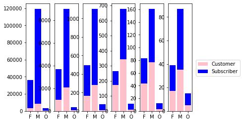

```python
plt.figure(figsize=[15,5]);
fig, (ax1, ax2, ax3, ax4, ax5, ax6) = plt.subplots(1, 6); # 1 row, 6 columns
ax1.bar(Type1.index,Type1['Customer'],color="pink",label='Customer')
ax1.bar(Type1.index,Type1['Subscriber'],color="blue",label='Subscriber',bottom=Type1['Customer'])

ax2.bar(Type2.index,Type2['Customer'],color="pink",label='Customer')
ax2.bar(Type2.index,Type2['Subscriber'],color="blue",label='Subscriber',bottom=Type2['Customer'])

ax3.bar(Type3.index,Type3['Customer'],color="pink",label='Customer')
ax3.bar(Type3.index,Type3['Subscriber'],color="blue",label='Subscriber',bottom=Type3['Customer'])

ax4.bar(Type4.index,Type4['Customer'],color="pink",label='Customer')
ax4.bar(Type4.index,Type4['Subscriber'],color="blue",label='Subscriber',bottom=Type4['Customer'])

ax5.bar(Type5.index,Type5['Customer'],color="pink",label='Customer')
ax5.bar(Type5.index,Type5['Subscriber'],color="blue",label='Subscriber',bottom=Type5['Customer'])

ax6.bar(Type6.index,Type6['Customer'],color="pink",label='Customer')
ax6.bar(Type6.index,Type6['Subscriber'],color="blue",label='Subscriber',bottom=Type6['Customer'])


plt.legend(bbox_to_anchor=(1.05, 0.5), loc='upper left')

plt.show()
```

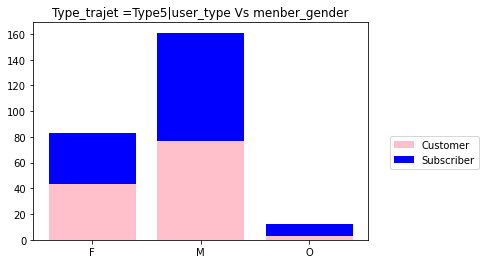

```python
fig, (ax5) = plt.subplots(1, 1)
ax5.bar(Type5.index,Type5['Customer'],color="pink",label='Customer')
ax5.bar(Type5.index,Type5['Subscriber'],color="blue",label='Subscriber',bottom=Type5['Customer'])
plt.legend(bbox_to_anchor=(1.05, 0.5), loc='upper left')

ax5.set_title('Type_trajet =Type5|user_type Vs menber_gender')
plt.show()
```

#### Question #15

Connaisant le sexe, le fait d'être client ou abonné dépend-il du fait que le vélo soit du type tout déplacement ou non?

```python
# Sous jeux de données par sexe
female= df_clean[df_clean['member_gender'] == 'Female']
male= df_clean[df_clean['member_gender'] == 'Male']
other =df_clean[df_clean['member_gender'] == 'Other']
```

### Les différents tableaux croisés type d'ulisateur par type de vélo connaissant le sexe

```python
# Transfortion en tableau croisé
fem=pd.pivot_table(female[['user_type','bike_share_for_all_trip']],index=['bike_share_for_all_trip'],columns=['user_type'],aggfunc=len)
oth=pd.pivot_table(other[['user_type','bike_share_for_all_trip']],index=['bike_share_for_all_trip'],columns=['user_type'],aggfunc=len)
mal=pd.pivot_table(male[['user_type','bike_share_for_all_trip']],index=['bike_share_for_all_trip'],columns=['user_type'],aggfunc=len)

print(f"Sahant que le member_gender = Female")
print(f'{fem}\n')
print(f"Sahant que le member_gender = Male")
print(f'{mal}\n')
print(f"Sahant que le member_gender = Other")
print(f'{oth}\n')
```

```
Sahant que le member_gender = Female
user_type                Customer  Subscriber
bike_share_for_all_trip
No                         4623.0     32588.0
Yes                           NaN      3594.0

Sahant que le member_gender = Male
user_type                Customer  Subscriber
bike_share_for_all_trip
No                        11493.0    105903.0
Yes                           NaN     13104.0

Sahant que le member_gender = Other
user_type                Customer  Subscriber
bike_share_for_all_trip
No                          450.0      2549.0
Yes                           NaN       648.0
```

```python
fem.fillna(0, inplace =True)
mal.fillna(0, inplace =True)
oth.fillna(0, inplace =True)
```

#### Visualisation #15

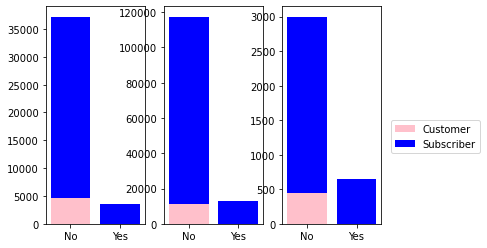

```python
plt.figure(figsize=[15,5]);
fig, (ax1, ax2, ax3) = plt.subplots(1, 3); # 1 row, 2 columns
ax1.bar(fem.index,fem['Customer'],color="pink",label='Customer')
ax1.bar(fem.index,fem['Subscriber'],color="blue",label='Subscriber',bottom=fem['Customer'])

ax2.bar(mal.index,mal['Customer'],color="pink",label='Customer')
ax2.bar(mal.index,mal['Subscriber'],color="blue",label='Subscriber',bottom=mal['Customer'])

ax3.bar(oth.index,oth['Customer'],color="pink",label='Customer')
ax3.bar(oth.index,oth['Subscriber'],color="blue",label='Subscriber',bottom=oth['Customer'])


plt.legend(bbox_to_anchor=(1.05, 0.5), loc='upper left')


plt.show()
```

#### Observation #15

Nous obervons dans ce graphe que aucun client n'a utilisé le vélo de type tout déplacement.

# Analyse des utilisateurs n'ayant pas précisé leur sexe

Le sous jeu de données nommé "sous_data" concerne les utilisateur pour lesquels les valeurs manquent pour des vaiables: "member_gender" et "member_birth_year". Dans la suite, nous analyserons ce jeu de données en nous focalisant sur notre objetif de prédiction du type d'utilisateur.

## Analyse Univariée

#### Question #1

Quel était le type d'utilisateur le plus fréquent au mois de Février?

```python
# Tranformation de la variable "user_type" en variable catégorielle
sous_data["user_type"] = sous_data["user_type"].astype("category")
```

#### Visualisation #1

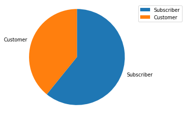

```python
# Observation des fréquences des abonnés et clients au mois de Février
sorted_counts =sous_data['user_type'].value_counts()
plt.pie(sorted_counts, labels = sorted_counts.index, startangle = 90, counterclock = False);
plt.legend(bbox_to_anchor=(1.05, 1.0), loc='upper left');
plt.axis('square');
```

#### Observation #1

D'après notre schema, nous constactons que les abonnés étaient les utilisateurs les plus nombreux n'ayant pas précisé leur sexe.

#### Question #2

Quel jour du mois ont-il effectué leur plus grand nombre de trajet?

#### Viualisation #2

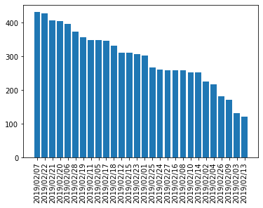

```python
# Observation du jour ayant eu plus d'enregitrement sans mention du sexe des utilisateurs
x = sous_data['start_time'].value_counts(sort=True).index
y = sous_data['start_time'].value_counts(sort=True)
plt.xticks(rotation=90)
plt.bar(x, y);
```

#### Observation #2

Nous observons de ce graphe que le 07 et le 22 Fevrier ont été les jours du mois pendant lesquels les utilisateurs n'ayant pas memtionné leur sexe avaient entrepris leur trajet.

#### Question #3

A quel moment de la journée a-t-il eu le plus de trajet?

#### Visualisation #3

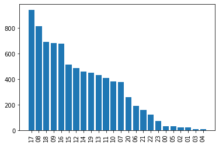

```python
# Observation du moment de la journée lors duquel les trajets sont les effectués
x = sous_data['start_period'].value_counts().index
y = sous_data['start_period'].value_counts()
plt.xticks(rotation=90)
plt.bar(x, y);
```

#### Observation #3

La plupart de trajet s'effectue autour de 17heures.